# Session 5: Database Software and Scaling your Analyses

Introduction to Web Scraping and Data Management for Social Scientists

Johannes B. Gruber

2026-07-24

# Introduction

## This Course

| Day | Session |
| --- | --- |
| 1 | Introduction |
| 2 | Data Structures and Wrangling |
| 3 | Working with Files |
| 4 | Linking and joining data & SQL |
| 5 | Database Software and Scaling your Analyses |
| 6 | Introduction to the Web |
| 7 | Static Web Pages |
| 8 | Application Programming Interface (APIs) |
| 9 | Interactive Web Pages |
| 10 | Building a Reproducible Research Project |

## The Plan for Today

In this session, you learn:

- Repetition: DBMS
- Working with PostgreSQL
- Working with text databases
- Benchmarking
- Final scaling tips

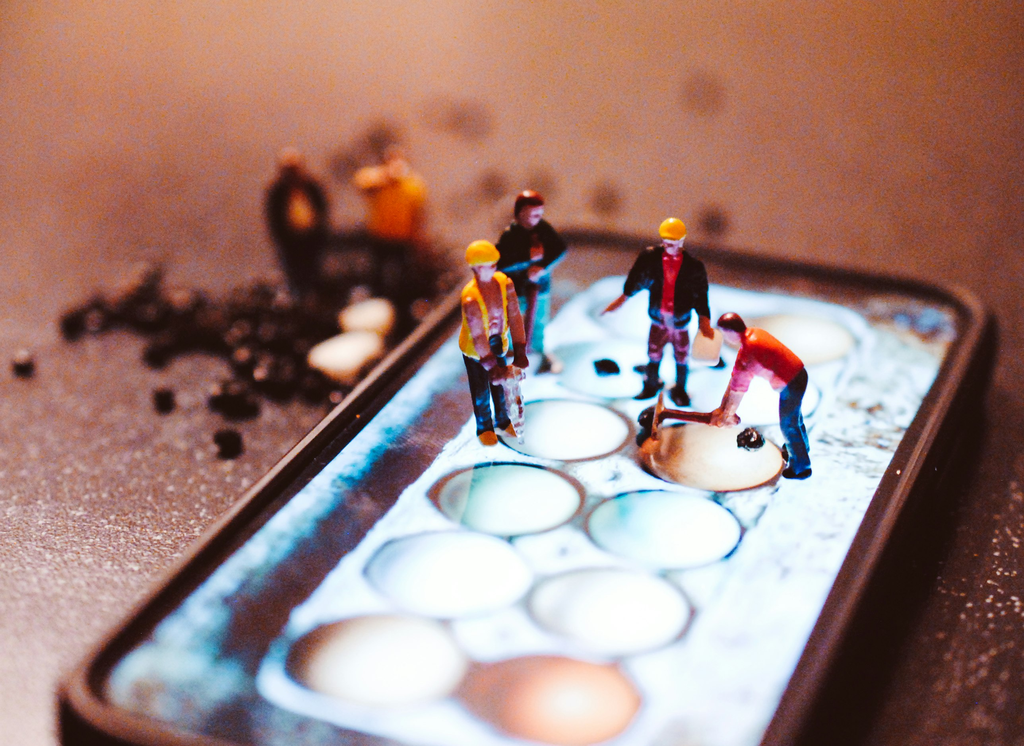

[Nik](https://unsplash.com/@helloimnik) via unsplash.com

# Databases

## DBMS: servers and clients

- most DBMS are set up in client-server architecture:
  - server: can be a computer somewhere or a process on your own computer that fulfills requests
  - DBMS server: contains the database and database management system
  - client: interacts with server (sends requests, receives responses)
  - DBMS client: can upload and retrieve data from server or send processing instructions
- Why though:
  - server can run on more powerful hardware somewhere else
  - requests from multiple users don’t interfere with each other
  - access control per user to support different roles

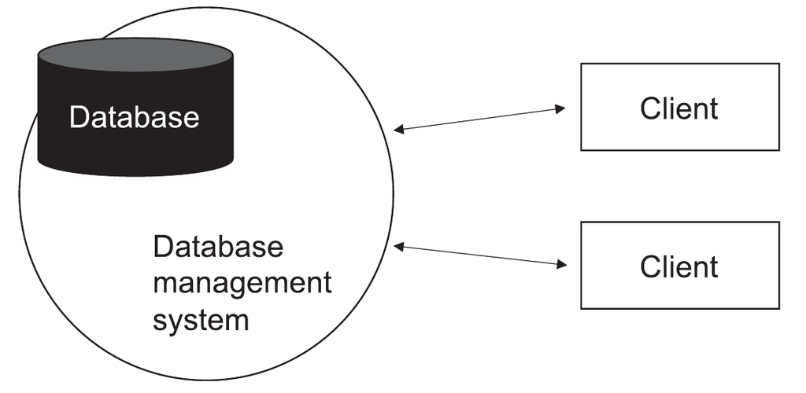

Interacting with a database management system from Weidmann (2023), p. 105.

## Got Server?

[figure not shown]

[figure not shown]

[figure not shown]

https://azure.microsoft.com/en-us/free/

[figure not shown]

## RDBMS software

- many popular choices alternatives:
  - Oracle Database
  - MySQL
  - Microsoft SQL Server
  - IBM Db2
  - Microsoft Access
  - SQLite (free software)
  - MariaDB (free software)
- all use slightly different dialects of `SQL`, but the core functionality is the same
- We will use `PostgreSQL`: free and open source, well-known, and many other programming languages and tools can interface to it

# Working with PostgreSQL

## Installation

We are using Docker to spin up a local server that has PostgreSQL already installed.

You have to type this into your **Terminal**(!):

```bash
docker-compose -f 05_Scaling_Reporting_and_Database_Software/data/docker-compose.yml up -d
```

This is running the compose file below:

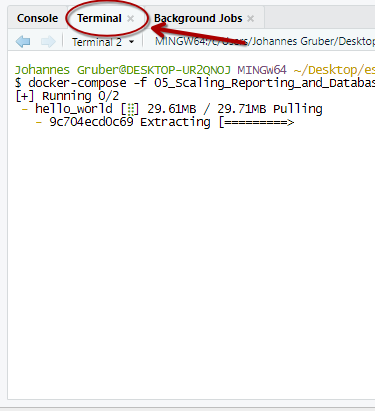

```yaml
services:
  postgres:
    image: postgres
    container_name: postgres_db
    environment:
      POSTGRES_USER: postgres
      POSTGRES_PASSWORD: pgpasswd
      POSTGRES_DB: dbintro
    ports:
      - "5432:5432"
    volumes:
      - pgdata:/var/lib/postgresql/data

volumes:
  pgdata:
```

## Connecting from `R`

```r
library(DBI)
library(RPostgres)
db <- dbConnect(
  Postgres(),
  dbname = "dbintro",
  host = "localhost", # Make sure to specify the host
  port = 5432L,
  user = "postgres",
  password = "pgpasswd"
)
```

Note: if you did not set up your own local PostgreSQL server, you can use mine for now. Just replace `localhost` with `204.168.185.249` and `user = "postgres"` with your name in lowercase (e.g., `user = "johannes"`)

Let’s fill this database with the `nycflights13` flights data:

```r
library(nycflights13)
dbWriteTable(db, name = "airports", value = airports, overwrite = TRUE)
dbWriteTable(db, name = "flights", value = flights, overwrite = TRUE)
dbWriteTable(db, name = "weather", value = weather, overwrite = TRUE)
dbWriteTable(db, name = "planes", value = planes, overwrite = TRUE)
dbWriteTable(db, name = "airlines", value = airlines, overwrite = TRUE)
```

## Connecting from the terminal

```bash
docker exec -it -u postgres postgres_db psql -d dbintro
```

Inside the Docker container (that is the name of a server running via docker), you can list tables with:

```sql
\dt
```

You can run `SQL` operations in here without `R`:

```sql
SELECT * FROM airports;
#                     ^
```

Note that commands are only executed when `SQL` encounters a `;`!

- Exit a long print with `q`

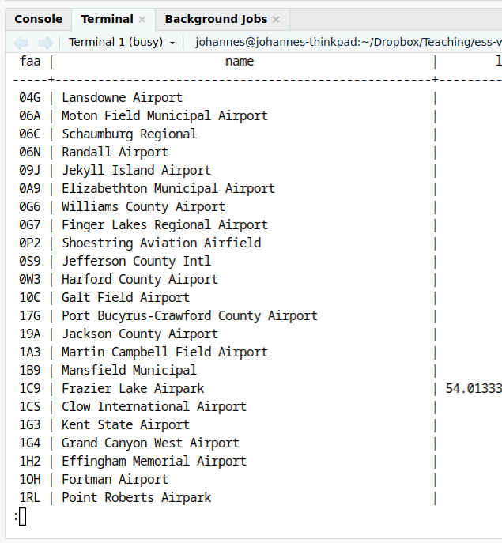

## Using Adminer Web-GUI

Access by typing `localhost:8080` in your browser

[figure not shown]

**Note**

Adminer is only one of several Web-GUIs. pgAdmin would be another popular alternative with more features.

## Working with `PostgreSQL`: pretty similar to SQLite…

But not the same…

```r
dbExecute(
  db,
  "CREATE TABLE df1 (
              id SERIAL PRIMARY KEY,
              capital_letters VARCHAR(1) CHECK (capital_letters ~ '^[A-Z]$'),
              my_date DATE CHECK (my_date > '2000-01-01')
          )"
)
```

```
[1] 0
```

## Working with `PostgreSQL` and `dbplyr`: the same as `SQLite`

I copied this from the last session, and it works just as well:

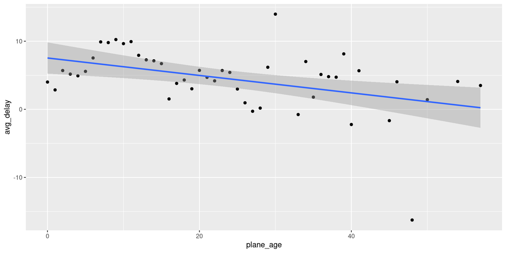

```r
tbl(db, "flights") |>
  inner_join(tbl(db, "planes"), by = "tailnum", suffix = c("", "_plane")) |>
  mutate(plane_age = year - year_plane) |>
  select(arr_delay, plane_age) |>
  filter(!is.na(arr_delay), !is.na(plane_age)) |>
  collect() |>
  group_by(plane_age) |>
  summarise(avg_delay = mean(arr_delay)) |>
  ggplot(aes(x = plane_age, y = avg_delay)) +
  geom_point() +
  geom_smooth(method = "lm", formula = y ~ x)
```

## User-based authentication

Imagine this:

- you have a team of researchers
- some are responsible for data gathering (annotation, webscraping, conducting survey waves, etc.)
- some are responsible for data analysis
- you are responsible for data management and public reporting
- You want to make sure that:
  - researchers in team gathering do not overwrite each others changes
  - team analysis always has the newest data
  - the summary data on the website is online as soon as possible
- with `PostgreSQL` you can make sure the two groups don disrupt each other and the most recent results are pull from the database automatically

## User-based authentication: users

We create three new users:

- one for the one researchers in the gatherer group
- one for the one analyser in the analysis group
- one called “reader” which represents the general public

```r
dbExecute(db, "CREATE USER gatherer WITH ENCRYPTED PASSWORD 'supersecret'")
```

```
[1] 0
```

```r
dbExecute(db, "CREATE USER analyser WITH ENCRYPTED PASSWORD 'supersecret'")
```

```
[1] 0
```

```r
dbExecute(db, "CREATE USER reader WITH ENCRYPTED PASSWORD 'supersecret'")
```

```
[1] 0
```

We can look at users:

```r
dbGetQuery(db, "SELECT usename FROM pg_user")
```

```
   usename
1 postgres
2 gatherer
3 analyser
4   reader
```

## User-based authentication: users

Let’s log in as analyser:

```r
db_analyser <- dbConnect(
  Postgres(),
  dbname = "dbintro",
  host = "localhost", # Make sure to specify the host
  port = 5432L,
  user = "analyser",
  password = "supersecret"
)
```

## User-based authentication: roles

So far, neither of the new users can do anything:

```r
tbl(db_analyser, "flights")
```

```
Error in `dbplyr_query_fields()`:
! Can't query fields.
ℹ Using SQL: SELECT * FROM "flights" AS "q01" WHERE (0 = 1)
Caused by error:
! Failed to fetch row : ERROR:  permission denied for table flights
```

They have to be assigned roles first

## User-based authentication: roles

We first give the “gatherer” user permission to update a table:

```r
dbExecute(db, "GRANT UPDATE,INSERT ON flights TO gatherer")
```

```
[1] 0
```

Since we do not fully trust the analyser, we give them read-only access to flights, but access to everything in `df1`, which we pretend that the results of the analysis are stored in:

```r
dbExecute(db, "GRANT SELECT ON flights TO analyser")
```

```
[1] 0
```

```r
dbExecute(db, "GRANT ALL PRIVILEGES ON df1 TO analyser")
```

```
[1] 0
```

Finally, the public gets selected access to only some columns in the results table:

```r
dbExecute(db, "GRANT SELECT (capital_letters) ON df1 TO reader")
```

```
[1] 0
```

## User-based authentication: roles (analyser)

Still logged in as the analyser, let’s try to access the data again:

```r
tbl(db_analyser, "flights")
```

```
# A query:  ?? x 19
# Database: postgres  [analyser@localhost:5432/dbintro]
    year month   day dep_time sched_dep_time dep_delay arr_time sched_arr_time
   <int> <int> <int>    <int>          <int>     <dbl>    <int>          <int>
 1  2013     1     1      517            515         2      830            819
 2  2013     1     1      533            529         4      850            830
 3  2013     1     1      542            540         2      923            850
 4  2013     1     1      544            545        -1     1004           1022
 5  2013     1     1      554            600        -6      812            837
 6  2013     1     1      554            558        -4      740            728
 7  2013     1     1      555            600        -5      913            854
 8  2013     1     1      557            600        -3      709            723
 9  2013     1     1      557            600        -3      838            846
10  2013     1     1      558            600        -2      753            745
# ℹ more rows
# ℹ 11 more variables: arr_delay <dbl>, carrier <chr>, flight <int>,
#   tailnum <chr>, origin <chr>, dest <chr>, air_time <dbl>, distance <dbl>,
#   hour <dbl>, minute <dbl>, time_hour <dttm>
```

But we still can’t make changes:

```r
dbExecute(
  db_analyser,
  "INSERT INTO flights (year)
            VALUES (2013)"
)
```

```
Error:
! Failed to fetch row : ERROR:  permission denied for table flights
```

We can add data to the tables that we were granted access to though:

```r
dbExecute(
  db_analyser,
  "INSERT INTO df1
            VALUES (1, 'A', '2025-07-11')"
)
```

```
[1] 1
```

## User-based authentication: roles (gatherer)

Logging in as the gatherer, we can add new cases:

```r
db_gatherer <- dbConnect(
  Postgres(),
  dbname = "dbintro",
  host = "localhost", # Make sure to specify the host
  port = 5432L,
  user = "gatherer",
  password = "supersecret"
)
dbExecute(
  db_gatherer,
  "INSERT INTO flights (year)
            VALUES (2013)"
)
```

```
[1] 1
```

## User-based authentication: roles (reader)

Logging in as the reader, we can can’t change anything, but can only read specific columns:

```r
db_reader <- dbConnect(
  Postgres(),
  dbname = "dbintro",
  host = "localhost", # Make sure to specify the host
  port = 5432L,
  user = "reader",
  password = "supersecret"
)
```

```r
dbGetQuery(db_reader, "SELECT * FROM df1")
```

```
Error:
! Failed to fetch row : ERROR:  permission denied for table df1
```

```r
dbGetQuery(db_reader, "SELECT capital_letters FROM df1")
```

```
  capital_letters
1               A
```

Now we could give out this user to the public without the need to worry that they change or read anything they are not supposed to.

## Exercises 1

Using the `PostgreSQL` database or the `SQLite` database from session 4:

1. Right join `results_state` and `facts` using `dbplyr` instead of `dbGetQuery`
2. Recreate the table `results_state_time` by querying and joining from db (using `dbplyr` instead of `dbGetQuery`).
3. Recreate `results_state_facts` using `dbplyr`. Don’t forget to add `total_votes` and `pct_votes`
4. Extract the SQL query from your code in 3. and run it with `dbGetQuery`

# Working with text data in AmCAT

## Why AmCAT

- Optimized to store, annotate, preprocess, search, share and present **text** data collections
- For teams or individual researchers
- Fine-grained access control
- Free and Open Source

[figure not shown]

## Installation

Same as with `PostgreSQL`, we can use Docker.

```bash
docker-compose -f 05_Scaling_Reporting_and_Database_Software/data/docker-compose-amcat.yml up -d
```

## Connecting from the terminal

Creating a test index:

```bash
docker exec -it amcat4 amcat4 create-test-index
```

Configure the AmCAT server:

```bash
docker exec -it amcat4 amcat4 config
```

## Connecting from `R`

We need to log in, which you can do without a user by default (use `204.168.185.249´ instead of`localhost` again for a public server):

```r
# remotes::install_github("ccs-amsterdam/amcat4r")
library(amcat4r)
amcat_login("http://localhost/api")
```

We can have a look at the example corpus with:

```r
query_documents(index = "state_of_the_union")
```

```
# A tibble: 200 × 3
   .id      title                   date
   <id_col> <chr>                   <dttm>
 1 kNR…OM8  1790: George Washington 1790-01-08 00:00:00
 2 kdR…OM9  1790: George Washington 1790-12-08 00:00:00
 3 ktR…OM9  1791: George Washington 1791-10-25 00:00:00
 4 k9R…OM9  1792: George Washington 1792-11-06 00:00:00
 5 lNR…OM9  1793: George Washington 1793-12-03 00:00:00
 6 ldR…OM9  1794: George Washington 1794-11-19 00:00:00
 7 ltR…OM9  1795: George Washington 1795-12-08 00:00:00
 8 l9R…OM9  1796: George Washington 1796-12-07 00:00:00
 9 mNR…OM9  1797: John Adams        1797-11-22 00:00:00
10 mdR…OM9  1798: John Adams        1798-12-08 00:00:00
# ℹ 190 more rows
```

## Dataset

Load data from Rauh and Schwalbach (2020) into AmCAT:

```r
if (!"houseofcommons" %in% list_indexes()$id) {
  corp_hoc_df <- readRDS(
    "../03_Working_with_Files/data/Corp_HouseOfCommons_V2.rds"
  ) |>
    mutate(date = as.Date(date)) |>
    rename(title = agenda) |>
    filter(!is.na(date)) |>
    replace_na(list(title = "", text = "")) |>
    select(-party.facts.id)

  # speed this up by only using a sample
  # corp_hoc_df <- corp_hoc_df |>
  #   sample_n(size = 500)

  # define types of fields
  fields <- list(
    date = "date",
    text = "text",
    title = "text",
    speechnumber = "integer",
    speaker = "keyword",
    party = "keyword",
    chair = "boolean",
    terms = "integer",
    parliament = "keyword",
    iso3country = "keyword"
  )
  # create the index
  create_index(
    index = "houseofcommons",
    name = "House Of Commons",
    description = "HouseOfCommons",
    create_fields = fields
  )

  # upload the data
  upload_documents(
    "houseofcommons",
    documents = corp_hoc_df,
    chunk_size = 1000,
    verbose = TRUE
  )
}
```

## AmCAT GUI

- Access at: http://localhost/
- Search and explore data
- Queries are made in Elasticsearch’s “mini-language” for query strings (https://bit.ly/elastic_queries)
- Let’s see some examples!

[Tom And Jerry Searching GIF](https://tenor.com/view/tom-and-jerry-searching-gif-25603936)from

## AmCAT API

- R and Python packages
- OpenAPI specifications
- Search, upload, download, modify data (e.g., add keywords/categories)
- User and access management
- Easy way to make research reproducible by querying data for analysis
- Great for larger than memory data sets

[interactive chart not shown]

## AmCAT API

```r
query_documents(index = "houseofcommons", queries = "*Europ*")
```

```
# A tibble: 200 × 3
   .id      date                title
   <id_col> <dttm>              <chr>
 1 VOB…lIp  2002-02-07 00:00:00 ""
 2 deB…lIp  2002-02-07 00:00:00 ""
 3 g-B…lIp  2002-02-08 00:00:00 "Disadvantaged Areas [Prayers]"
 4 kOB…lIp  2002-02-08 00:00:00 "Disadvantaged Areas [Prayers]"
 5 p-B…lIp  2002-02-08 00:00:00 "Disadvantaged Areas [Prayers]"
 6 qOB…lIp  2002-02-08 00:00:00 "Disadvantaged Areas [Prayers]"
 7 zuB…lIp  2002-02-08 00:00:00 "Disadvantaged Areas [Prayers]"
 8 2OB…lIq  2002-02-08 00:00:00 "Disadvantaged Areas [Prayers]"
 9 3-B…lIq  2002-02-08 00:00:00 "Disadvantaged Areas [Prayers]"
10 4OB…lIq  2002-02-08 00:00:00 "Disadvantaged Areas [Prayers]"
# ℹ 190 more rows
```

```r
query_documents(index = "houseofcommons", queries = '"European Union" OR EU')
```

```
# A tibble: 200 × 3
   .id      date                title
   <id_col> <dttm>              <chr>
 1 p-B…lIp  2002-02-08 00:00:00 Disadvantaged Areas [Prayers]
 2 3-B…lIq  2002-02-08 00:00:00 Disadvantaged Areas [Prayers]
 3 7eB…lIq  2002-02-11 00:00:00 Eu Defence Capability [Oral Answers To Question…
 4 7uB…lIq  2002-02-11 00:00:00 Eu Defence Capability [Oral Answers To Question…
 5 7-B…lIq  2002-02-11 00:00:00 Eu Defence Capability [Oral Answers To Question…
 6 8OB…lIq  2002-02-11 00:00:00 Eu Defence Capability [Oral Answers To Question…
 7 8eB…lIq  2002-02-11 00:00:00 Eu Defence Capability [Oral Answers To Question…
 8 8uB…lIq  2002-02-11 00:00:00 Eu Defence Capability [Oral Answers To Question…
 9 8-B…lIq  2002-02-11 00:00:00 Eu Defence Capability [Oral Answers To Question…
10 9OB…lIq  2002-02-11 00:00:00 Eu Defence Capability [Oral Answers To Question…
# ℹ 190 more rows
```

```r
query_aggregate(
  index = "houseofcommons",
  filters = list(party = c("Con", "Lab"), date = list(gte = "2000-01-01")),
  axes = list(list(field = "party"), list(field = "date", interval = "year")),
  queries = '"European Union" OR EU'
)
```

```
# A tibble: 40 × 3
   party date_year      n
   <chr> <chr>      <int>
 1 Lab   2000-01-01  1340
 2 Lab   2001-01-01  1214
 3 Lab   2002-01-01  1242
 4 Lab   2003-01-01  1733
 5 Lab   2004-01-01  1507
 6 Lab   2005-01-01  1392
 7 Lab   2006-01-01  1160
 8 Lab   2007-01-01  1308
 9 Lab   2008-01-01  2407
10 Lab   2009-01-01  1051
# ℹ 30 more rows
```

## Access Control in Amcat4 enables Non-Consumptive Research

- Sharing data helps scientific progress!
- Copyright and/or (privacy-)sensitive material can not be easily shared
- Definition: non-consumptive research involves the **use of computational methods** to analyze data **without giving access to the data itself**

[figure not shown]

[figure not shown]

[figure not shown]

## Exercises 2

1. Connect to your own AmCAT server (alternatively, connect to mine)
2. Create a new index and add some toy data to it that has: a date, a title, and a text field
3. Query all documents from your index
4. query the documents from the “houseofcommons” index that have:
   1. mentions of protest, protesters, protester, or protesting
   2. no mentions of protestant, in addition to 4.1
   3. contain speeches by the Conservative Party, in addition to 4.1 and 4.2 (hint: use a filter)
5. Count (hint: aggregate) how often the Conservatives mention protest words each month after 2000

# Scaling your research

## Benchmarking

- when your data grows, it becomes important that your code is fast, since it is applied to many cases
- benchmarking helps you identify bottlenecks
- it can make the difference between minutes and days whether your code is optimized for speed

## Benchmarking with `bench`

Basic syntax:

1. define functions that wrap your code

```r
library(bench)
fun1 <- function() {
  1 + 1
}
fun2 <- function() {
  a <- 1
  b <- 1
  sum(c(a, b))
}
```

2. run `mark`

```r
res <- mark(simple = fun1(), complex = fun2())
```

3. check summary

```r
summary(res)
```

```
# A tibble: 2 × 6
  expression      min   median `itr/sec` mem_alloc `gc/sec`
  <bch:expr> <bch:tm> <bch:tm>     <dbl> <bch:byt>    <dbl>
1 simple     244.94ns 296.98ns  1916501.        0B        0
2 complex      1.16µs   1.19µs   630715.        0B        0
```

```r
summary(res, relative = TRUE)
```

```
# A tibble: 2 × 6
  expression   min median `itr/sec` mem_alloc `gc/sec`
  <bch:expr> <dbl>  <dbl>     <dbl>     <dbl>    <dbl>
1 simple      1      1         3.04       NaN      NaN
2 complex     4.72   4.01      1          NaN      NaN
```

## Benchmarking: in memory vs in database

1. define functions that wrap your code

```r
in_memory <- function() {
  nycflights13::flights |>
    inner_join(nycflights13::weather, by = c("time_hour", "origin")) |>
    filter(time_hour < "2013-03-01")
}

in_db <- function() {
  tbl(db, "flights") |>
    inner_join(tbl(db, "weather"), by = c("time_hour", "origin")) |>
    filter(time_hour < "2013-03-01") |>
    collect()
}
```

2. run `mark`

```r
res <- mark(
  in_memory = in_memory(),
  in_db = in_db(),
  check = FALSE,
  iterations = 15
)
```

3. check summary

```r
summary(res)
```

```
# A tibble: 2 × 6
  expression      min   median `itr/sec` mem_alloc `gc/sec`
  <bch:expr> <bch:tm> <bch:tm>     <dbl> <bch:byt>    <dbl>
1 in_memory    85.5ms    103ms      5.78   117.3MB     9.63
2 in_db       388.1ms    415ms      2.33    31.1MB     1.09
```

```r
summary(res, relative = TRUE)
```

```
# A tibble: 2 × 6
  expression   min median `itr/sec` mem_alloc `gc/sec`
  <bch:expr> <dbl>  <dbl>     <dbl>     <dbl>    <dbl>
1 in_memory   1      1         2.48      3.77     8.87
2 in_db       4.54   4.03      1         1        1
```

## Fix bottlenecks

```r
dbWriteTable(db, "flights_w_index", flights, overwrite = TRUE)
dbWriteTable(db, "weather_w_index", weather, overwrite = TRUE)
dbExecute(db, "CREATE INDEX ON flights_w_index (time_hour)")
```

```
[1] 0
```

```r
dbExecute(db, "CREATE INDEX ON weather_w_index (time_hour)")
```

```
[1] 0
```

1. define functions that wrap your code

```r
in_memory <- function() {
  nycflights13::flights |>
    inner_join(nycflights13::weather, by = c("time_hour", "origin")) |>
    filter(time_hour < "2013-03-01")
}

in_db <- function() {
  tbl(db, "flights") |>
    inner_join(tbl(db, "weather"), by = c("time_hour", "origin")) |>
    filter(time_hour < "2013-03-01") |>
    collect()
}

in_db_w_index <- function() {
  tbl(db, "flights_w_index") |>
    inner_join(tbl(db, "weather_w_index"), by = c("time_hour", "origin")) |>
    filter(time_hour < "2013-03-01") |>
    collect()
}
```

2. run `mark`

```r
res <- mark(
  in_memory = in_memory(),
  in_db = in_db(),
  in_db_w_index = in_db_w_index(),
  check = FALSE,
  iterations = 25
)
```

3. check summary

```r
summary(res)
```

```
# A tibble: 3 × 6
  expression         min   median `itr/sec` mem_alloc `gc/sec`
  <bch:expr>    <bch:tm> <bch:tm>     <dbl> <bch:byt>    <dbl>
1 in_memory       76.5ms    106ms      6.46   116.9MB   11.4
2 in_db          401.3ms    469ms      2.06    31.1MB    0.824
3 in_db_w_index  415.5ms    477ms      2.04    31.1MB    0.817
```

```r
summary(res, relative = TRUE)
```

```
# A tibble: 3 × 6
  expression      min median `itr/sec` mem_alloc `gc/sec`
  <bch:expr>    <dbl>  <dbl>     <dbl>     <dbl>    <dbl>
1 in_memory      1      1         3.16      3.76    13.9
2 in_db          5.25   4.43      1.01      1        1.01
3 in_db_w_index  5.43   4.51      1         1.00     1
```

# Data Management: Summary

## What for?

- enables new research questions by being able to combine and clean new data
- let’s you sleep easy at night
- makes your work transparent to others and yourself
- thinking about reproducibility from the start

## When to use files vs. databases

- often not clear from the start
- working with files is easier as a solo researchers (who keeps a clean project directory)
- when data changes regularly it makes sense to not add to the same file again and again
- when several researchers collaborate, a database solves many issues
- when you have text data, vectors, or complex elements, NoSQL databases like AmCAT or MongoDB can make sense

# When done, `dbDisconnect`

Whenever you are done working with a database, you should disconnect from it:

```r
dbDisconnect(db)
dbDisconnect(db_analyser)
dbDisconnect(db_gatherer)
dbDisconnect(db_reader)
```

- This closes the connection, discards all pending work, and frees resources

# Wrap Up

# References

Rauh, Christian, and Jan Schwalbach. 2020. “The ParlSpeech V2 data set: Full-text corpora of 6.3 million parliamentary speeches in the key legislative chambers of nine representative democracies.” Version V1. Harvard Dataverse. https://doi.org/10.7910/DVN/L4OAKN.

Weidmann, Nils B. 2023. *Data Management for Social Scientists: From Files to Databases*. 1st ed. Cambridge University Press. https://doi.org/10.1017/9781108990424.